# Filtering exome sequence data using an R (markdown) script

Axel Nohturfft

2019-11-28

# Intro

## Aims

With this script we’ll cover:

1. Using rmarkdown and generating an html report
2. Filtering a large data set (R data frame)
3. Using the very popular `dplyr` package

## R markdown

Like regular R scripts, rmarkdown scripts are just text files (with the .Rmd extension) that differ from regular R scripts in three principal ways:

1. In normal R scripts (.R files) text is interpreted by default **as code**, while comments have to be preceded by a ‘#’. Conversely, in rmarkdown scripts (.Rmd files) text is interpreted by default as **formatted comments**; code has to be enclosed in so-called ‘chunks’ that are framed by three back-ticks (see code). RStudio highlights these code chunks with a grey background.
2. In rmarkdown scripts the output from the code chunks is shown within the script itself.
3. Rmarkdown is extremely useful in generating very professional reports in any of various common formats (e.g. html, Word, PDF, Powerpoint)

More information about rmarkdown can be found [here](https://rmarkdown.rstudio.com/).

Although the best resource for rmarkdown is [this online book](https://bookdown.org/yihui/rmarkdown/).

If you plan to use rmarkdown in your work I recommend that you print out a copy of the [rmarkdown cheatsheet](https://rstudio.com/wp-content/uploads/2015/02/rmarkdown-cheatsheet.pdf) and hang it above your desk.

# Setup

## Parameters + packages

```r
lib.loc <- "/homedirs8/workshops/190301-R/packages_3_5_0"
stopifnot(file.exists(lib.loc))
.libPaths(lib.loc)
```

```r
library(magrittr, lib.loc=lib.loc)
library(dplyr, lib.loc=lib.loc)
library(stringi, lib.loc=lib.loc)
```

## Input data

```r
# This code assumes that the data file is in the working directory.
# Use setwd() to change the working directory or use the complete path to the data file below.
data.file <- "data/M003_annovar_hg19_multianno_crop.txt"
# Stop the script if the data file cannot be found in the current working directory:
stopifnot(file.exists(data.file))
cat("Data file: <tt><b>", data.file, "</b></tt>\n")
```

Data file: `data/M003_annovar_hg19_multianno_crop.txt`

## Read data

The ‘read.table()’ function is commonly used to import tabular data.

```r
# only 141 headers, but
m003 <- read.table(file=data.file, sep="\t", header=T, stringsAsFactors = FALSE)
# m003 <- read.table(file=data.file, sep="\t", header=F, nrows=1)
```

# Inspect the imported data

## Object class generated by read.table()

```r
class(m003)
```

```
[1] "data.frame"
```

## Number of rows and columns

```r
dim(m003)
```

```
[1] 34194   141
```

**Generating nicer output:**

```r
cat("Number of data columns:", ncol(m003))
```

Number of data columns: 141

```r
cat("Number of data rows:", nrow(m003))
```

Number of data rows: 34194

## Column headers:

```r
data.frame(Column.No=seq_len(ncol(m003)), Column.Name=names(m003)) %>%
  knitr::kable(., align=rep("c", ncol(m003)))
```

| Column.No | Column.Name |
| --- | --- |
| 1 | Chr |
| 2 | Start |
| 3 | End |
| 4 | Ref |
| 5 | Alt |
| 6 | Func.refGene |
| 7 | Gene.refGene |
| 8 | GeneDetail.refGene |
| 9 | ExonicFunc.refGene |
| 10 | AAChange.refGene |
| 11 | Func.ensGene |
| 12 | Gene.ensGene |
| 13 | GeneDetail.ensGene |
| 14 | ExonicFunc.ensGene |
| 15 | AAChange.ensGene |
| 16 | cytoBand |
| 17 | genomicSuperDups |
| 18 | X1000g2015aug_all |
| 19 | esp6500siv2_ea |
| 20 | esp6500siv2_aa |
| 21 | esp6500siv2_all |
| 22 | ExAC_ALL |
| 23 | ExAC_AFR |
| 24 | ExAC_AMR |
| 25 | ExAC_EAS |
| 26 | ExAC_FIN |
| 27 | ExAC_NFE |
| 28 | ExAC_OTH |
| 29 | ExAC_SAS |
| 30 | Kaviar_AF |

[output cut: 111 more lines]

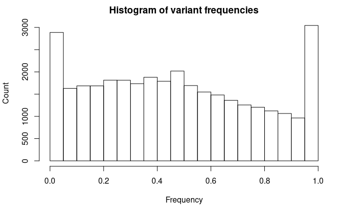

```r
m003$gnomAD_exome_ALL[!is.na(m003$gnomAD_exome_ALL)] %>%
  as.numeric(na.rm=T) %>%
  hist(., main="Histogram of variant frequencies", xlab="Frequency", ylab="Count")
```

Keep only rare variants (frequency of less than 0.0001)

```r
# Here we are using the 'filter()' function from the dplyr package to select rows based on specified criteria.
# help(filter, package="dplyr")
m003 %>%
  filter(gnomAD_exome_ALL < 0.0001) %>%
  nrow
```

```
[1] 33445
```

```r
# 33445
```

Should include variants that have never been seen before (i.e. not in database, represented as NA in the data frame):

Get rid of silent mutations (synonymous):

The Gene.refGene column contains the gene symbols - save in a variable:

```r
interesting.variants <- m003 %>%
  filter(gnomAD_exome_ALL < 0.01 | is.na(gnomAD_exome_ALL)) %>%
  filter(! ExonicFunc.refGene %in% c(NA, "synonymous SNV", "unknown", "nonframeshift insertion", "nonframeshift deletion" )) %>%
  .$Gene.refGene %>%
  as.character
# 361
```

How many are there?

```r
length(interesting.variants)
```

```
[1] 493
```

Any duplicates?

```r
any(duplicated(interesting.variants))
```

```
[1] TRUE
```

Remove duplicates:

```r
interesting.variants <- unique(interesting.variants)
length(interesting.variants) # 493
```

```
[1] 305
```

Sort alphabetically:

```r
interesting.variants <- sort(interesting.variants)
```

Print:

```r
cat(interesting.variants, sep=", ")
```

```
ABHD14B, ACBD5, ACTL7B, ADGRF2, ADGRF5, AK2, AKAP7, ALDH1L2, ALX1, AMY1A;AMY1B;AMY1C, ANK3, ANKRD20A1;ANKRD20A3, ANKRD20A2;ANKRD20A3, ANKRD20A4, ANKRD36, ANKRD36B, ANKRD36C, ANKS1A, ANLN, AQP7, AQR, ARHGEF17, ARHGEF19, ARHGEF35, ARHGEF4, ARMC3, ARPP21, ATXN3, B4GALNT1, BDP1, BRAP, BRAT1, BRF1, C12or…
```

Save in a file:

```r
out.file <- "interesting_variants.txt"
cat(interesting.variants, sep="\n", file=out.file)
```

# Session info

To properly document your data analysis always include the session info, which includes e.g. the versions of R and of any packages used:

[session information not shown]